# BaSiC

Wei Sun

1/7/2019

This R markdown file illustrate the usage of R package `basic` with application on the bulk smaple and single cell sequencing data generated by Gawad, C., Koh, W., & Quake, S. R. (2014). *Dissecting the clonal origins of childhood acute lymphoblastic leukemia by single-cell genomics*. PNAS, 111(50), 17947-17952. This study collected bulk and single cell sequencing data from six childhood acute lymphoblastic leukemia (ALL) patients. This is a type of cancer with relatively small number of somatic mutations. Altogether 278 mutations are identified from 6 patients, with the number of mutations per patient varies from 10 to 105. After identifing somatic mutations from exome-seq of bulk samples, they sequenced 1,479 single tumor cells from these six patients using target sequencing with high depth.

BaSiC is designed to analyze exome-seq data with a relatively large number of mutations per sample. In addition, Basic exploit the read count information to impute mutation calls when sequence depth in single cells are relatively low. Since this dataset has relatively small number of mutations and high read-depth in single cells, it is not the type data that BaSiC is designed for. Neverthless, we apply BaSiC to demonstrate its performance in this dataset.

```r
library(basic)
library(gridExtra)
library(ggplot2)
library(ggcorrplot)
library(reshape2)
```

We downloaded the information of somatic mutations of bulk tumor samples from [Supplementary Dataset_S01](https://www.pnas.org/highwire/filestream/617852/field_highwire_adjunct_files/1/pnas.1420822111.sd01.xlsx). This file provides mutation location and VAF, but does not provide read-depth information. We downloaded the raw sequence data (fastq files) from NCBI SRA, mapped the reads to hg19 using BWA with default options, and used the following script to process these raw data to obtain read coutn information.

```
#!/bin/bash
java -Xmx24g -jar path2Picard/picard.jar SortSam \
      INPUT=SRR1517762_hg19.sam \
      OUTPUT=SRR1517762_hg19_sorted.bam \
      SORT_ORDER=coordinate

java -Xmx24g -jar path2Picard/picard.jar AddOrReplaceReadGroups \
      INPUT=SRR1517762_hg19_sorted.bam \
      OUTPUT=SRR1517762_hg19_sorted_RG.bam \
      ID=FLOWCELL6.LANE6\
      SORT_ORDER=coordinate \
      LB=SRR1517762 PL=ILLUMINA \
      SM=SRR1517762 \
      PU=FLOWCELL6.LANE6

java -Xmx24g -jar path2Picard/picard.jar MarkDuplicates REMOVE_DUPLICATES=true \
      INPUT=SRR1517762_hg19_sorted_RG.bam \
      OUTPUT=SRR1517762_hg19_sorted_RG_dedup.bam \
      METRICS_FILE=SRR1517762_hg19_sorted_RG_dedup_metric.txt

samtools index SRR1517762_hg19_sorted_RG_dedup.bam

java -Xmx7g -jar GenomeAnalysisTK-3.6/GenomeAnalysisTK.jar \
      -T ASEReadCounter \
      -R /fh/fast/sun_w/research/data/human/hg19/Homo_sapiens_assembly19.fasta \
      -I SRR1517762_hg19_sorted_RG_dedup.bam \
      -o ./output/SRR1517762_hg19_site2.txt \
      -sites vcf_sites2.vcf \
      -minDepth 1 \
      --minMappingQuality 1 \
      --minBaseQuality 0 \
      --disable_auto_index_creation_and_locking_when_reading_rods
```

First read in the somatic mutaton calls and read-depth information from bulk tumor

```r
mutBk = read.table("data/Final_Mutation_Calls_with_counts.txt", sep="\t",
                  as.is=TRUE, header=TRUE)
dim(mutBk)
```

```
## [1] 278  18
```

```r
mutBk[1:2,]
```

```
##     Patient Chromosome  Position Reference Variant
## 1 Patient 1       chr1 151512803         G       A
## 2 Patient 1       chr1 151735456         C       T
##   Confirmed.Normal.Var.Freq Confirmed.Tumor.Var.Freq  Gene Type Effect
## 1                       0.0                     19.7 TUFT1 UTR5   <NA>
## 2                       0.3                     29.4  OAZ3 UTR5   <NA>
##   refCount altCount totalCount lowMAPQDepth lowBaseQDepth rawDepth
## 1       74       13         87            0             0       87
## 2      113       39        152            0             0      152
##   otherBases improperPairs
## 1          0             0
## 2          0             0
```

```r
table(mutBk$Patient, useNA="ifany")
```

```
##
## Patient 1 Patient 2 Patient 3 Patient 4 Patient 5 Patient 6
##        20        16        49        78       105        10
```

```r
table(mutBk$Type, mutBk$Effect, useNA="ifany")
```

```
##
##            nonsynonymous SNV stopgain SNV synonymous SNV unknown <NA>
##   coding                 111            7             26       2    0
##   intronic                 0            0              0       0   50
##   ncRNA                    0            0              0       0   12
##   splicing                 0            0              0       0    3
##   upstream                 0            0              0       0    3
##   UTR3                     0            0              0       0   49
##   UTR5                     0            0              0       0   15
```

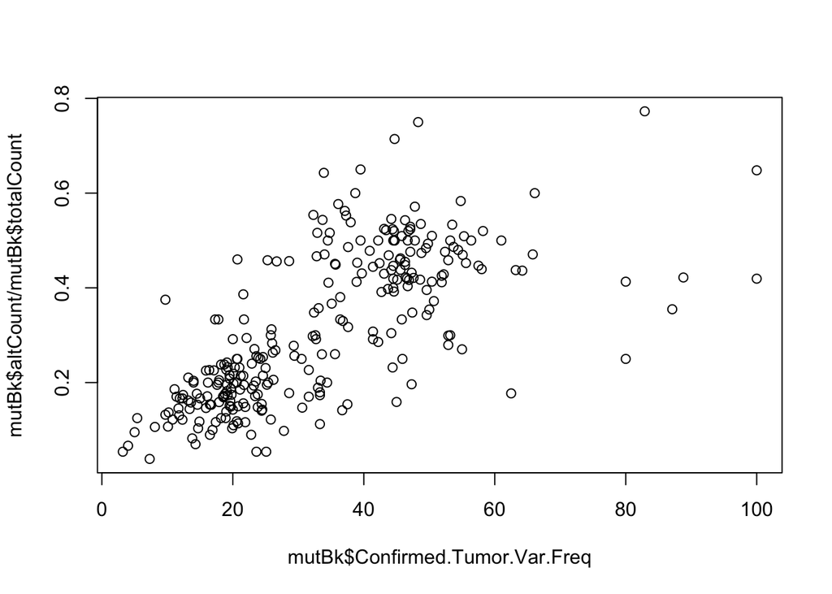

```r
plot(mutBk$Confirmed.Tumor.Var.Freq, mutBk$altCount/mutBk$totalCount)
```

Next we read in the single cell data

```
## [1] "patient 1"
```

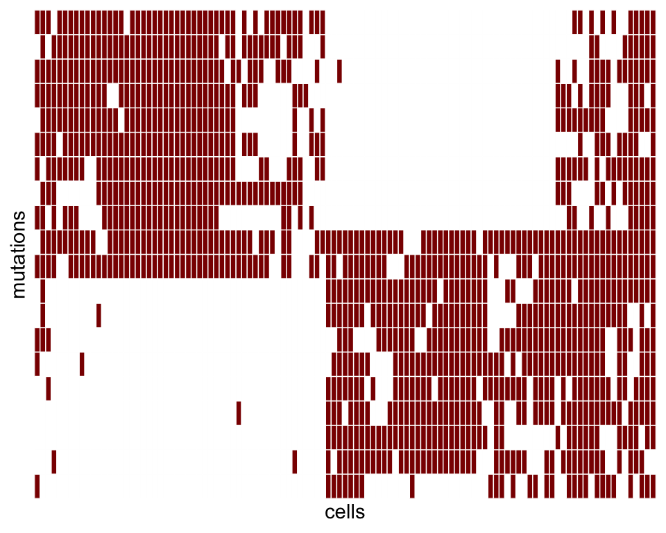

```
## [1] "patient 2"
```

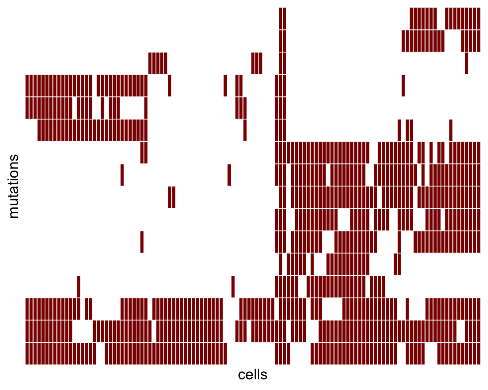

```
## [1] "patient 3"
```

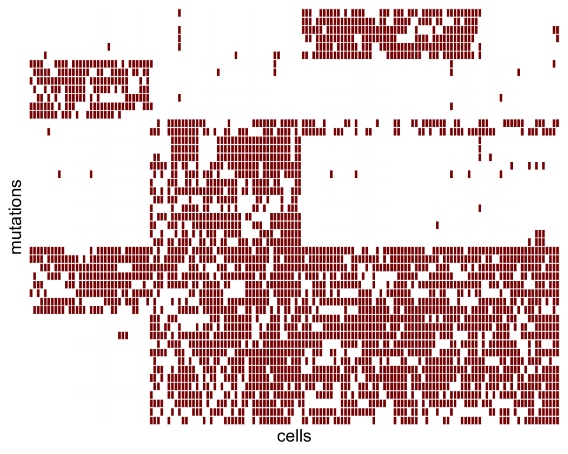

```
## [1] "patient 4"
```

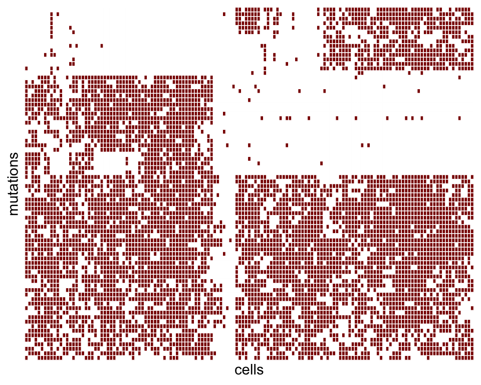

```
## [1] "patient 5"
```

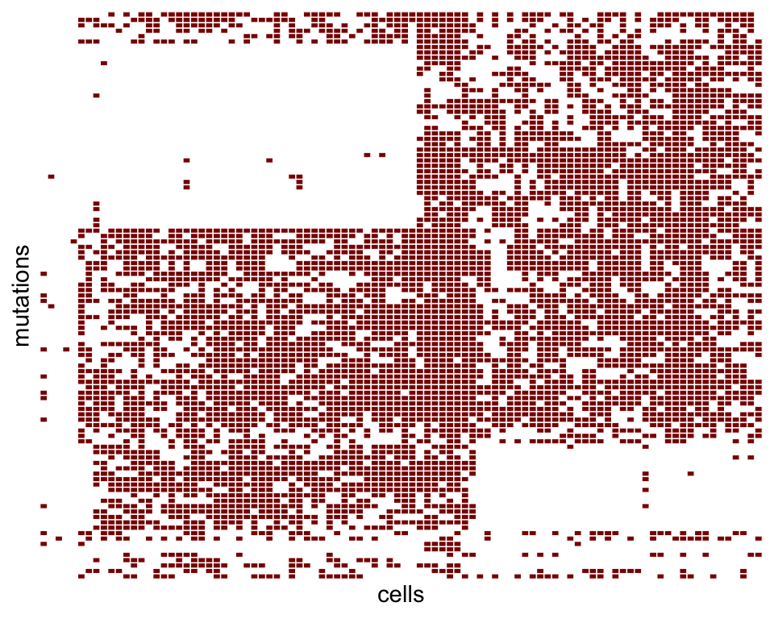

```
## [1] "patient 6"
```

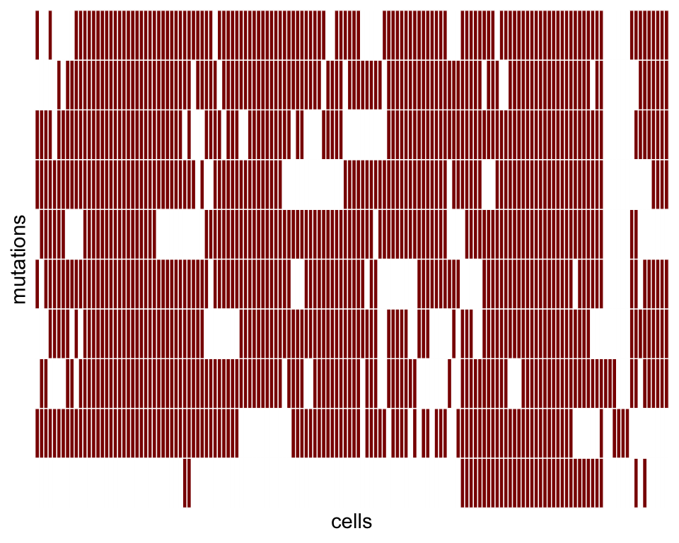

```r
mutS = clustS = list()

for(i in 1:6){
  fname = sprintf("data/pat_%d_cluster_dat", i)
  mut.i = read.table(fname, header=TRUE)
  mut.i = data.matrix(mut.i)
  t1    = mut.i[,which(colnames(mut.i) != "clusters")]
  clustS[[i]] = mut.i[,which(colnames(mut.i) == "clusters")]

  h1 = hclust(dist(t1))
  h2 = hclust(dist(t(t1)))
  t1 = t1[h1$order, h2$order]
  mutS[[i]] = t1
  rownames(t1) = 1:nrow(t1)
  colnames(t1) = 1:ncol(t1)

  t2 = melt(t1)
  names(t2)[1:2] = c("cell", "mutation")

  col2use = c("white", "darkred")

  g1 = ggplot(t2, aes(cell, mutation)) + theme_grey() +
    geom_tile(aes(fill = as.factor(value)), color = "white", size=0.25) +
    ylab("mutations") + xlab("cells") +
    scale_x_discrete(expand = c(0, 0)) +
    scale_y_discrete(expand = c(0, 0)) +
    scale_fill_manual(values=col2use) +
    theme(axis.text.x=element_blank(), legend.position = "none")
  print(sprintf("patient %d", i))
  print(g1)
}
```